# Functions

lession 7

Eviatar Guttman

Last updated: 05-07-2021

```r
library(tidyverse)
library(patchwork)
library(Hmisc)
```

# 1 intro

פונקציות מאפשרות אוטומציה במקום להשתמש ב copy-paste.

ייתרונות:  
1. שימוש בשם אינפורמטיבי להקל על הבנת התהליך המבוצע.  
2. עדכון קוד במקום אחד.  
3. מזעור טעויות.

נשקול לכתוב פונקציה כאשר העתקנו קוד באמצעות copy paste יותר מפעמיים.

## 1.1 motivation

**דוגמא:**  
ברצוננו לנרמל את ערכי הוקטורים ב-data.frame כך שערכי הווקטורים יהיו בין 0 לבין 1.

```r
df <- tibble::tibble(
  a = rnorm(10,3, 5),
  b = rnorm(10),
  c = rnorm(10)
)
```

```r
df$a <- (df$a - min(df$a, na.rm = TRUE)) /
  (max(df$a, na.rm = TRUE) - min(df$a, na.rm = TRUE))

df$b <- (df$b - min(df$b, na.rm = TRUE)) /
  (max(df$b, na.rm = TRUE) - min(df$a, na.rm = TRUE))

df$c <- (df$c - min(df$c, na.rm = TRUE)) /
  (max(df$c, na.rm = TRUE) - min(df$c, na.rm = TRUE))
```

בשורה השניה יש טעות.  
בקוד שיוצר את המשתנה המנורמל, יש רק משתנה אחד, ווקטור אותו רוצים לנרמל.  
נמשוך ווקטור אחד מהנתונים ונעבוד איתו כדי ליצור את הפונקציה:

```r
(x <- df$a)
```

```
##  [1] -1.6232909  1.4488472  4.0573467  3.5126746 -0.5552971  3.3622112
##  [7]  7.3076063 13.0892630 -2.6053478  7.1323362
```

```r
(x - min(x, na.rm = TRUE)) / (max(x, na.rm = TRUE) - min(x, na.rm = TRUE))
```

```
##  [1] 0.06257287 0.25831765 0.42452116 0.38981677 0.13062131 0.38022982
##  [7] 0.63161516 1.00000000 0.00000000 0.62044762
```

```r
range(x) # returns a vector containing the minimum and maximum of arguments.
```

```
## [1] -2.605348 13.089263
```

כעת הקוד פשוט יותר, וניתן להכניסו לפונקציה:

```r
rescale <- function(x) {

  rng <- range(x, na.rm = TRUE)
  (x - rng[1]) / (rng[2] - rng[1])

  }
```

נבדוק שהפונקציה עובדת

```r
rescale(c(0, 5, 10))
```

```
## [1] 0.0 0.5 1.0
```

## 1.2 function tracture

פונקציה מורכבת משלושה חלקים: שם, ארגומנטים וגוף.  
המבנה הכללי הוא:

```r
function_name <- function(list of arguuments){

  # body
  # something is happening

  }
```

לא לכל הפונקציות יש את שלושת הרכיבים. למשל, ישנן פונקציות פרמיטיביות כמו `sum` או- `[` שנכתבו בשפת C.

```r
sum
## function (..., na.rm = FALSE)  .Primitive("sum")


`[`
## .Primitive("[")
```

**השם** מתאר את מה שהפונקציה עושה. השם צריך להיות קצר ואינפורמטיבי. לא כדאי להשתמש בשמות שכבר תפוסים ע"י חבילות אחרות בשימוש, ובטח לא במילים שמורות.  
לא לעשות את זה:

```r
T <- FALSE
c <- 10
```

**ארגומנטים** הם ה- inputs של הפונקציה. (בדוגמא שלנו יש ארגומנט יחיד)  
ניתן לראותם באמצעות:

```r
formals(rescale)
```

**גוף** הפונקציה זה הקוד שעושה את העבודה ונמצא בין הסוגריים המסולסלים `{`. ניתן לראותו באמצעות:

```r
body(rescale)
## {
##     rng <- range(x, na.rm = TRUE)
##     (x - rng[1])/(rng[2] - rng[1])
## }
```

כדי להבהיר מה הקוד עושה השתמשו בהערות עם `#` המסבירות למה… הקוד לא יכול להסביר מדוע עשיתם משהו, מדוע בחרתם בגישה זו או אחרת.  
מנגד, מוטב לא לכתוב הערות שמסבירות מה נעשה או איך. אם הקוד לא מספיק ברור, כדאי לכתוב אותו מחדש באופן יותר ברור.

נוח לחלק את הקוד באמצעות:

```r
# Load data --------------------------------------

# Plot data --------------------------------------
```

Ctrl + Shift + R ייצר שורה חדה בקוד.

תהליך החשיבה הוא:  
תחילה, להבין מה הפונקציה עושה וליישם באמצעות קוד פשוט. לאחר מכן לכתוב את זה כפונקציה. כדאי לבדוק את הפונקציה inputs שונים.

```r
rescale(c(-10, 0, 10))
```

```
## [1] 0.0 0.5 1.0
```

```r
rescale(c(1, 2, 3, NA, 5))
```

```
## [1] 0.00 0.25 0.50   NA 1.00
```

כעת אפשר לכתוב:

```r
df$a <- rescale(df$a)
df$b <- rescale(df$b)
df$c <- rescale(df$c)
```

צמצמנו את האפשרות לטעויות אבל עדיין אנו מעתיקים את אותו קוד 3 פעמים. (כאשר נדון ב- iteration נראה עוד אפשרויות לצמצום שורות הקוד)  
אם הדרישות מהקוד הן שונות אפשר לעדכן זאת במקום אחד

```r
x <- c(1:10, Inf)

rescale(x)
```

```
##  [1]   0   0   0   0   0   0   0   0   0   0 NaN
```

```r
rescale <- function(x) {
  rng <- range(x, na.rm = TRUE, finite = TRUE)
  (x - rng[1]) / (rng[2] - rng[1])
}

rescale(x)
```

```
##  [1] 0.0000000 0.1111111 0.2222222 0.3333333 0.4444444 0.5555556 0.6666667
##  [8] 0.7777778 0.8888889 1.0000000       Inf
```

## 1.3 function is an object

פונקציה ב-R, היא אובייקט:  
היא מקבלת שם עם אותו אופרטור `<-`.  
כאשר הפונקציה קצרה ולא חשובה, לא חייבים לתת לה שם:

```r
sapply(mtcars, function(x) length(unique(x)))
```

```
##  mpg  cyl disp   hp drat   wt qsec   vs   am gear carb
##   25    3   27   22   22   29   30    2    2    3    6
```

```r
dplyr::select(mtcars,function(x) !is.numeric(x))
## data frame with 0 columns and 32 rows
```

אפשר לאגד פונקציות ברשימה:

```r
funs <- list(
  half = function(x) x / 2,
  double = function(x) x * 2
)

funs$double(10)
```

```
## [1] 20
```

```r
funs$half(10)
```

```
## [1] 5
```

אפשר לשמור את הארגומנטים של הפונקציה במבנה נפרד ולהזין אותם באמצעות `do.call`

```r
mean(1:10, na.rm = TRUE)
```

```
## [1] 5.5
```

```r
args <- list(1:10, na.rm = TRUE)

do.call(mean, args)
```

```
## [1] 5.5
```

ל-`do.call` יש שני ארגומנטים: פונקציה לקרוא לה ורשימה של הארגומנטים. כלומר, ניתן להזין פונקציה כארגומנט לפונקציה אחרת.  
`purrr::invoke(mean, args)` מיישמת את אותו הדבר.

## 1.4 exercise

1. כתבו פונקציה שמחשבת את השונות של ווקטור:

$$Var(x) = \frac{1}{n-1} \sum_{i = 1}^n(x_i -\overline{x})^2$$

2. כתבו את הפונקציה rescale כך שהערך Inf ימופה ל 1 והערך Inf- ימופה ל 0.
3. כתבו פונקציה בשם both_na, המקבלת שני ווקטורים באותו אורך ומציינת את מספר המקרים בהם שני הווקטורים (באותו מקום) הם NA.  
   כלומר, בווקטורים הבאים:

```r
a <- c(1, NA, NA)
b <– c(NA, NA, 3)
```

מספר המקרים הוא 1. גם ב-a וגם ב-b ערך התא השני הוא NA

## 1.5 function forms

כל מה שקיים ב-R הוא אובייקט כל מה שקורה ב-R זו קריאה לפונקציה  
לא כל הפונציות נראות אותו הדבר.

Function calls come in four varieties:

- **prefix**: the function name comes before its arguments, like `foofy(a, b, c)`. These constitute of the majority of function calls in R.
- **infix**: the function name comes in between its arguments, like `x + y`. Infix forms are used for many mathematical operators, and for user-defined functions that begin and end with %.
- **replacement**: functions that replace values by assignment, like `names(df) <- c("a", "b", "c")`. They actually look like prefix functions.
- **special**: functions like `[[`, if, and for. While they don’t have a consistent structure, they play important roles in R’s syntax.

**אנחנו נדבר רק על prefix functions.**

# 2 conditional excecution

פונקציות כמו `if` ו-`switch` מאפשרות להריץ קוד שונה בהתאם ל-input.  
**שימוש ב - `if`**

```r
if (condition){
  # code executed when condition is TRUE
}



if (condition) {
  # code executed when condition is TRUE
} else {
  # code executed when condition is FALSE
}


# or in short:
if (condition) true_action
if (condition) true_action else false_action
```

אם `condition` הוא`TRUE` ה-`true_action` מיושם (evaluated). אם `condition` הוא `FALSE`, ה-`false_action` האופציונאלי מיושם.

כאשר לא מגדירים `else` וה-`condition` הוא `FALSE`, הפונקציה מחזירה `NULL`. יש יישומים המשתמשים בתכונה זו.  
המבנה של הכתיבה הוא:  
- פותחים סוגריים מסולסלים ועוברים שורה.  
- בשורה הבאה הקוד מתחיל לאחר שני רווחים.  
- סגירה של סוגריים מסולסלים בשורה משלה, אלא אם כן מגיע else לאחר מכן.

```r
if (y < 0 && debug) {
  message("Y is negative")
}

if (y == 0) {
  log(x)
} else {
  y ^ x
}
```

אם הביטוי קצר מאד , אפשר לוותר על הסוגריים המסולסלים ולכתוב את הביטוי בשורה אחת.

```r
y <- 10

if (y < 20) "Too low" else "Too high"
```

```
## [1] "Too low"
```

אפשר לשרשר מספר תנאים:

```r
if (this) {
  # do that
} else if (that) {
  # do something else
} else {
  #
}

# for example:
grade <- function(x) {
  if (x > 90) {
    "A"
  } else if (x > 80) {
    "B"
  } else if (x > 50) {
    "C"
  } else {
    "F"
  }
}
```

אם שרשרתם הרבה תנאים, כדאי לחשוב על כתיבה מחדש. טכניקה אפשרית היא שימוש ב `switch`:

```r
function(x, y, op) {
   switch(op,
     plus = x + y,
     minus = x - y,
     times = x * y,
     divide = x / y,
     stop("Unknown op!")
   )
}
```

`if` מחזיר ערך כך שניתן לשמור את התוצאה:

```r
x1 <- if (TRUE) 1 else 2
x2 <- if (FALSE) 1 else 2

c(x1, x2)
```

```
## [1] 1 2
```

התוצאה של יישום (evaluation) ה-`condition` צריכה להסתיים ב-`TRUE` או `FALSE`.

```r
if ("x") 1
```

```
## Error in if ("x") 1: argument is not interpretable as logical
```

```r
if(logical()) 1
```

```
## Error in if (logical()) 1: argument is of length zero
```

```r
if(NA) 1
```

```
## Error in if (NA) 1: missing value where TRUE/FALSE needed
```

```r
# remembering the 2nd session that non zero numerics will be coerced into TRUE:
x <- 0.001

as.logical(x)
```

```
## [1] TRUE
```

```r
if(x) 1 else "zero"
```

```
## [1] 1
```

```r
if(!x) 1 else "zero"
```

```
## [1] "zero"
```

אם הזנתם ווקטור באורך גדול מ-1 תקבלו אזהרה:

```r
if (c(TRUE, FALSE)) "אמת במקום הראשון בוקטור"
```

[output not shown]

`if` עובד רק עם ערך יחיד של `TRUE` או `FALSE` . ווקטור באורך 1. סקלר.  
אם יש לכם וקטור ארוך יותר השתמשו בפונקציות ווקטוריות כמו `base::ifelse` או `dplyr::if_else`

```r
x <- 1:10

dplyr::if_else(x %% 2 == 0, "even", "odd")
```

```
##  [1] "odd"  "even" "odd"  "even" "odd"  "even" "odd"  "even" "odd"  "even"
```

אפשרות יותר כללית היא להשתמש ב-`dplyr::case_when`

```r
dplyr::case_when(
  x %% 6 == 0 ~ "by 6",
  x %% 4 == 0 ~ "by 4",
  x %% 2 == 0 ~ "by 2",
  is.na(x) ~ "???",
  TRUE ~ as.character(x)
)
```

```
##  [1] "1"    "by 2" "3"    "by 4" "5"    "by 6" "7"    "by 4" "9"    "by 2"
```

הנה פונקציה המחזירה וקטור לוגי המציין האם כל תא בווקטור הוא עם שם או לא

```r
has_name <- function(x) {
  nms <- names(x)
  if (is.null(nms)) {
    rep(FALSE, length(x))
  } else {
    !is.na(nms) & nms != ""
  }
}

(x <-c(a = 1, b = 2, c = 3, 5:7))
## a b c
## 1 2 3 5 6 7

has_name(x)
```

```
## [1]  TRUE  TRUE  TRUE FALSE FALSE FALSE
```

הפונקציות `&` ו- `|` הן ווקטוריות.  
פונקציה ווקטורית מקיימת שני תנאים:  
1. הוקטור שהיא מחזירה הוא באותו אורך של הוקטור שנכנס.  
2. התוצאה המחושבת בתא בודד (cell) תהיה זהה למצב בו הפעלתם את הפונקציה רק על אותו התא.

ל- `&` ו- `|` יש מקבילות סקלארות: `&&`, `||`.

גם `==` היא ווקטורית. תחליפים סקלארים הם `all` ו-`any` המסכמים את הוקטור לתנאי לוגי יחיד - סקלר.

```r
# & Vs && (similar to | vs ||)

10 > 9                      # single TRUE
```

```
## [1] TRUE
```

```r
1:5 > 3                     # a logical vector
```

```
## [1] FALSE FALSE FALSE  TRUE  TRUE
```

```r
# & is vectorized:
10 > 9 & 1:5 > 3
```

```
## [1] FALSE FALSE FALSE  TRUE  TRUE
```

```r
9 > 10 & 1:5 > 3
```

```
## [1] FALSE FALSE FALSE FALSE FALSE
```

```r
# && is not vectorized, it will take the first value:
10 > 9 && 1:5 > 3
```

```
## [1] FALSE
```

```r
9 > 10 && 1:5 > 3
```

```
## [1] FALSE
```

```r
10 > 9 && 4:5 > 3         # 10 > 9 and also 4 > 3
```

```
## [1] TRUE
```

```r
# '==' vs any or all:
# '==' is vectorized
3 == 1:5
```

```
## [1] FALSE FALSE  TRUE FALSE FALSE
```

```r
# 'any()' and 'all()' flattens the vector:
any(1:5 == 3)
```

```
## [1] TRUE
```

```r
all(1:5 == 3)
```

```
## [1] FALSE
```

```r
all(1:5 > 0.9)
```

```
## [1] TRUE
```

תכונה נוספת של && (וגם של ||) היא : short-circuiting.  
בביטוי:

`cond1` `&&` `cond2` `&&` `cond3` `&&` `...`

ה-&& יבצע evaluation ל- `cond2` רק אם `cond1` התברר כ-`TRUE`. באופן דומה, evaluation ל-`cond3` יבוצע רק עם ה-evaluation ל-`cond2` התברר כ-`TRUE`.  
זה מאפשר לבצע מספר בדיקות אחת אחרי השנייה, ולהפסיק ברגע שאחת מהן מתבררת כ-FALSE.  
למשל, הנה פונקציה שבודקת האם וקטור הוא וקטור של הסתברויות:

```r
check_prob = function(probs){
    is.numeric(probs) &
    length(probs) > 1 &
    sum(probs) == 1
}

check_prob(c(0.2, 0.4, 0.4))
```

```
## [1] TRUE
```

```r
check_prob(letters)
```

```
## Error in sum(probs): invalid 'type' (character) of argument
```

```r
# The error comes from:
sum(letters)
```

```
## Error in sum(letters): invalid 'type' (character) of argument
```

```r
is.numeric(letters)
```

```
## [1] FALSE
```

אם נזין את `letters` תוך שימוש ב-short circuit, ה-evaluation ייפסק כבר בשורה הראשונה.

```r
check_prob = function(probs){
  is.numeric(probs) &&
    length(probs) > 1 &&
    sum(probs) == 1
}

check_prob(letters)
```

```
## [1] FALSE
```

אם עליכם להשתמש בשילוב של תנאים לוגיים, בביטוי `If`, אז good practice זה להשתמש במקבילות הסלקריות: `&&` ו- `||`.

```r
if(condition1 && condition2) { expression }

if(condition1 || condition2) { expression }
```

## 2.1 exercise

כתבו פונקציה שמברכת ב“בוקר טוב”, “אחה”צ טובים“, או”ערב טוב" בהתאם לשעות היום.  
לצורך בדיקת השעה השתמשו בארגומנט הזמן בפונקציה: `lubridate::now`.

# 3 Return values

פונקציה מחזירה את הערך האחרון שמחושב.  
אפשר להחזיר ערך מוקדם עם `return`.

```r
f1 <- function(){
  x <- 1
  x + 2
  x + 3
  }

f1()
```

```
## [1] 4
```

```r
f1 <- function(){
  x <- 1
  return(x + 2)
  x + 3
}

f1()
```

```
## [1] 3
```

דוגמא מעשית

```r
complicated_function <- function(x, y, z) {
  if (length(x) == 0 || length(y) == 0) {
    return(0)
  }

  # Complicated code here
}
```

אפשר להפוך את הביטויים של if כדי להתחיל מהחלק הפשוט.

```r
# one option
f <- function() {
  if (x) {
    # Do
    # something
    # that
    # takes
    # many
    # lines
    # to
    # express
  } else {
    # return something short
  }
}

# replace positions:

f <- function() {
  if (!x) {
    return(something_short)
  }

  # Do
  # something
  # that
  # takes
  # many
  # lines
  # to
  # express
}
```

כך, קל יותר להבין את הקוד.

# 4 function arguments

ארגומנטים נחלקים לשני סוגים עיקריים: ה -data, וה- details של איך לבצע את החישובים.  
למשל, ב -`log`, ה-data זה הוקטור x, וה-details זה הבסיס של הלוגריתם.  
בד“כ הארגומנט של ה-data מגיע ראשון. הארגומנטים של ה-details מגיעים אח”כ ובד"כ יש להם ערך ברירת מחדל.  
למשל, הפונקציה הבאה מחשבת רווח בר סמך סביב הממוצע של משתנה מקרי:

```r
# Compute confidence interval around mean using normal approximation
mean_ci <- function(x, conf = 0.95) {
  se <- sd(x) / sqrt(length(x))
  alpha <- 1 - conf
  mean(x) + se * qnorm(c(alpha / 2, 1 - alpha / 2))
}

x <- runif(100)

mean_ci(x)
```

```
## [1] 0.4312353 0.5488073
```

```r
mean_ci(x, conf = 0.99)
```

```
## [1] 0.4127634 0.5672792
```

בד“כ, נבחר את ערך ברירת המחדל לערך הנפוץ ביותר.  
אחרת, בוחרים את הערך כך המשתמש יהיה מודע למה שקורה בפונקציה. למשל, בד”כ בוחרים את `na.rm` להיות `FALSE`, כדי שהמשתמש יהיה מודע לקיום ערכים חסרים.  
בקריאה לפונקציה ניתן להשמיט את שם הארגומנט. אבל, כאשר משנים את ערך ברירת המחדל, כדאי לקרוא לארגומנט בשם.

```r
# Good
mean(1:10, na.rm = TRUE)

# Bad
mean(x = 1:10, , FALSE)
mean(, TRUE, x = c(1:10, NA))
```

כדאי לכתוב עם רווחים כמו באנגלית:

```r
# Good
average <- mean(feet / 12 + inches, na.rm = TRUE)

# Bad
average<-mean(feet/12+inches,na.rm=TRUE)
```

## 4.1 common object names

- וקטורים ב- x, y, z
- וקטורים של משקולות ב- w
- טבלת נתונים ב- df
- אינדקסים נומריים ב – i , j
- אורך של וקטור או מספר שורות ב- n

## 4.2 checking argument values

הפונקציה הבאה מחשבת ממוצע משוקלל:

```r
wt_mean <- function(x, w) {
  sum(x * w) / sum(w)
}
```

אם נזין שני ווקטורים שאורך אחד הוא מכפלה של השני נקבל תוצעה:

```r
wt_mean(1:6, 1:3)
```

```
## [1] 7.666667
```

זה לא מצב רצוי. אפשר להשתמש בכלים המחזירים error או message או warning כדי ליידע את המשתמש:

**Error**

```r
wt_mean <- function(x, w) {

  if (length(x) != length(w)) {
    stop("`x` and `w` must be the same length", call. = FALSE)
  }

  sum(w * x) / sum(w)
}

wt_mean(1:6, 1:3)
```

```
## Error: `x` and `w` must be the same length
```

**warning**

```r
wt_mean <- function(x, w) {

  if (length(x) != length(w)) {
    warning("`x` and `w` shuld be the same length", call. = TRUE)
  }

  sum(w * x) / sum(w)
}

wt_mean(1:6, 1:3)
```

```
## Warning in wt_mean(1:6, 1:3): `x` and `w` shuld be the same length
## [1] 7.666667
```

**message**

```r
wt_mean <- function(x, w) {

  if (length(x) != length(w)) {
    message("`x` and `w` are not the same length, the shorter vector was recycled")
  }

  sum(w * x) / sum(w)
}


wt_mean(1:6, 1:3)
## `x` and `w` are not the same length, the shorter vector was recycled
## [1] 7.666667
```

דרך נוספת לקבל error היא להשתמש ב- `stopifnot` המוודאת שתנאי אכן מתקיים:

```r
wt_mean <- function(x, w, na.rm = FALSE) {

  stopifnot(is.logical(na.rm), length(na.rm) == 1)
  stopifnot(length(x) == length(w))

  if (na.rm) {

    miss <- is.na(x) | is.na(w)
    x <- x[!miss]
    w <- w[!miss]
  }

  sum(w * x) / sum(w)
}


wt_mean(1:6, 6:1, na.rm = "foo")
```

```
## Error in wt_mean(1:6, 6:1, na.rm = "foo"): is.logical(na.rm) is not TRUE
```

```r
wt_mean(1:6, 3:1, na.rm = T)
```

```
## Error in wt_mean(1:6, 3:1, na.rm = T): length(x) == length(w) is not TRUE
```

```r
wt_mean(1:6, 6:1, na.rm = T)
```

```
## [1] 2.666667
```

בשורה הראשונה בפונקציה אנו מוודאים שהארגומנט של na.rm הוא לוגי ואורכו 1. בשורה השניה מוודאים שאורך שני הווקטורים זהה.  
ה- `if` בודק האם קיים ערך חסר באחד מהווקטורים. אם כן, בשני הווקטורים המיקום של הערך החסר מוסר.

# 5 dot dot dot …

פונקציות רבות מקבלות מספר שרירותי כלשהו של ארגומנטים ב- inputs.

```r
sum(1, 2, 3, 4, 5, 6, 7, 8, 9, 10)

stringr::str_c("a", "b", "c", "d", "e", "f")
```

הביטוי ‘…’ תופש מספר כלשהו של ארגומנטים שבמצב אחר לא מסתדרים יחד. זה שימושי כי אפשר לשלוח זאת לפונקציה פנימית שהפונקציה שלכם כתובה מסביבה.

```r
# example 1
commas <- function(...){

 stringr::str_c(..., collapse = ", ")
}

commas(letters[1:10])
```

```
## [1] "a, b, c, d, e, f, g, h, i, j"
```

```r
# example 2
inner_function <- function(y, z) {

  list(y = y, z = z)
}


outer_function <- function(x, ...) {

  inner_function(...)
}

str(outer_function(x = 1, y = 2, z = 3))
```

```
## List of 2
##  $ y: num 2
##  $ z: num 3
```

```r
# example 3
# lapply() uses ... to pass na.rm on to mean():
x <- list(c(1, 3, NA), c(4, NA, 6))

str(lapply(x, mean, na.rm = TRUE))
```

```
## List of 2
##  $ : num 2
##  $ : num 5
```

צריך להיזהר בשימוש בטכניקה זו, ארגומנטים שנכתבו תוך שגיאת כתיב לא יביאו ל-error:

```r
x <- c(1, 2)

sum(x, na.mr = TRUE)
```

```
## [1] 4
```

```r
sum(1, 2, NA, na_rm = TRUE)
```

```
## [1] NA
```

אם אתם רוצים רק לתפוש את הערכים של … בכתיבת הפונקציה השתמשו ב- list(…)

```r
i04 <- function(...) {
  list(...)
}

str(i04(a = 1, b = 2))
```

```
## List of 2
##  $ a: num 1
##  $ b: num 2
```

## 5.1 excersize

1. מה התוצאה של הביטוי `commas(letters, collapse = "-")`. מדוע זה קורה ואיך פותרים זאת?
2. מה הארגומנט trim עושה בפונקציה mean(), ומתי הוא שימושי?
3. ערך ברירת המחדל בפונקציה `cor()` בארגומנט ה- `method` הוא: c(“pearson”, “kendall”, “spearman”). מה המשמעות ואיזה ערך משמש כברירת מחדל?

# 6 Pipable functions

כדאי לדעת מהו סוג האובייקט שהפונקציה מחזירה. לדוגמא, הפונקציות המרכזיות ב-`dplyr` (mutate, summarize, arrange, select, filter ) מחזירות ב-output data.frame. שני סוגים של pipeable :

**transformations**, an object is passed to the function’s first argument and a modified object is returned.

**side-effects**, the passed object is not transformed. Instead, the function performs an action on the object, like drawing a plot or saving a file. Side-effects functions should “invisibly” return the first argument, so that while they’re not printed they can still be used in a pipeline.

```r
show_missings <- function(df) {
  n <- sum(is.na(df))
  cat("Missing values: ", n, "\n", sep = "")

  invisible(df)
}
```

The `invisible()` means that the input df doesn’t get printed out.  
And we can still use it in a pipe:

```r
show_missings(mtcars)
## Missing values: 0

class(x)
```

```
## [1] "numeric"
```

```r
dim(x)
## NULL

mtcars %>%
  show_missings() %>%
  mutate(mpg = ifelse(mpg < 20, NA, mpg)) %>%
  show_missings()
## Missing values: 0
## Missing values: 18
```

# 7 lexical scoping

נושא זה עוסק במציאת הערך הקשור לשם (באמצעות `<-` ).

## 7.1 Name masking

שמות שמוגדרים בתוך הפונקציה ממסכים שמות שהוגדרו מחוץ לפונקציה

```r
x <- 10
y <- 20

g02 <- function() {

  x <- 1
  y <- 2
  c(x, y)
}

g02()
```

```
## [1] 1 2
```

אם השם לא הוגדר בתוך הפונקציה, R מחפשת אותו ‘קומה’ אחת למעלה:  
המינוח הנכון הוא in the parent environment.

```r
x <- 2

g03 <- function() {

  y <- 1
  c(x, y)
}

g03()
```

```
## [1] 2 1
```

```r
# And this doesn't change the previous value of y
y
```

```
## [1] 20
```

אותם כללים תקפים גם אם הפונקציה הוגדרה בתוך פונקציה אחרת.

## 7.2 Functions vs. variables.

אותו כלל גם תקף לפונקציות:

```r
g07 <- function(x) x + 1

g08 <- function() {

  g07 <- function(x) x + 100
  g07(10)
}

g08()
```

```
## [1] 110
```

כאשר נותנים את אותו השם לפונקציה ולאובייקטים שאינם פונקציות, R מתעלמת מהאובייקטים שאינם פונקציות. כדאי להימנע ממצבים אלה:

```r
g09 <- function(x) x + 100

g10 <- function() {

  g09 <- 10
  g09(g09)
}

g10()
```

```
## [1] 110
```

## 7.3 A fresh start

כל פעם שקוראים לפונקציה, החישוב נעשה מחדש באופן עצמאי.

```r
g11 <- function() {

  if (!exists("a")) {
    a <- 1
  } else {
    a <- a + 1
  }

  a
}

g11()
```

```
## [1] 1
```

```r
g11()
```

```
## [1] 1
```

## 7.4 Dynamic lookup

R מחפשת ערכים כאשר הפונקציה “רצה”, לא כאשר היא נוצרת. התוצאה של פונקציה עשויה להשתנות בהתאם למצב האובייקטים מחוץ לפונקציה

```r
g12 <- function() x + 1

x <- 15
g12()
```

```
## [1] 16
```

```r
x <- 20

g12()
```

```
## [1] 21
```

זו עשויה להיות בעיה כאשר מגדירים פונקציה משתמשת באובייקטים הנמצאים ב –global environment. (יש פתרונות לזה, ראו פרק 6 בספר advanced R)

# 8 Lazy evaluation

הערכים ב-R, לא מחושבים עד לעת בהם הם נזקקים. כלומר, לא משתמשים בהם אלא אם כן קוראים להם. זו תכונה חשובה של R.  
הארגומנטים בפונקציה מוערכים (evaluated) רק כאשר הם נקראים לכך. למשל, בקוד הבא אין error משום שלא קוראים ל-y אף פעם:

```r
g13 <- function(x, y){

  x * 10
}

g13(4)
```

```
## [1] 40
```

אפשר גם:

```r
g13(x = 4, y = non_existing_variable)
```

```
## [1] 40
```

R לא מנסה לחפש את הערך non_existing_variable.

בביטוי `if else` רק ה חלק של ה- `TRUE` מוערך (evaluated).

```r
if (TRUE){
  12
} else {
  no_variable
}
```

```
## [1] 12
```

```r
# Or in the oposite direction:
if (FALSE){
  no_variable
} else {
  12
}
```

```
## [1] 12
```

זה מאפשר לכלול חישובים “כבדים” בפונקציות אשר יחושבו רק אם יהיה בהם צורך, וכך הקוד יעיל. החיסרון הוא שלא תמיד יודעים לצפות מה התוכנה תעשה ב-100%.

דוגמא:

```r
mean_of_that <- function(x, mean_of = mean(x)){

  x <- x[!is.na(x)]
  print(x)
  cat("The mean of x is", mean_of)
}

mean_of_that(c(1,2,3,4,NA))
```

```
## [1] 1 2 3 4
## The mean of x is 2.5
```

הפעם הראשונה שהפונקציה מחשבת את הערך של mean_of הוא בשורה האחרונה, זה קורה לאחר הסרת הערך החסר.

דוגמא נוספת:

```r
g14 <- function(a = Sys.time(), b = Sys.time(), c = Sys.time()){
  print(a)
  Sys.sleep(1)
  print(b)
  Sys.sleep(1)
  print(c)
}
g14()
```

```
## [1] "2021-07-05 13:14:10 IDT"
## [1] "2021-07-05 13:14:11 IDT"
## [1] "2021-07-05 13:14:13 IDT"
```

לכל תוצאה זמן אחר. כלומר, כל ביטוי הוערך בזמן אחר.

## 8.1 default arguments

ניתן להגדיר ערכי ברירת מחדל במונחים של ארגומנטים אחרים, או אפילו במונחים של משתנים שמוגדרים בשלב מאוחר יותר בפונקציה:

```r
h04 <- function(x = 1, y = x * 2, z = a + b) {

  a <- 10
  b <- 100

  c(x, y, z)
}

h04()
```

```
## [1]   1   2 110
```

זה אותו עיקרון שהראנו בפונקציה mean_of_that.  
על המשתמש לדעת את הסדר המדויק בו ארגומנטים של ברירת מחדל עוברים evaluation.  
ה- evaluation environment עבור ארגומנטים של ברירת מחדל שונה מזו של ארגומנטים שסופקו ע"י המשתמש.  
ה- evaluation environment של ארגומנט ברירת מחדל היא בתוך הפונקציה.

```r
h05 <- function(x = ls()) {

  a <- 1
  x
}

# ls() evaluated inside h05:
h05()
```

```
## [1] "a" "x"
```

```r
# ls() evaluated in global environment:
h05(ls())
```

```
##  [1] "args"           "check_prob"     "commas"         "df"
##  [5] "f"              "f1"             "funs"           "g02"
##  [9] "g03"            "g07"            "g08"            "g09"
## [13] "g10"            "g11"            "g12"            "g13"
## [17] "g14"            "h04"            "h05"            "has_name"
## [21] "i04"            "inner_function" "mean_ci"        "mean_of_that"
## [25] "outer_function" "rescale"        "show_missings"  "wt_mean"
## [29] "x"              "x1"             "x2"             "y"
```

## 8.2 promises

מה שמאפשר את הדפוס הזה הוא מבנה נתונים הנקרא **promise**.

ה- **promise** הוא מעין “מתכון” האומר ל-R היכן (באיזו environment) ואיך לבצע evaluation של הביטוי (expression) הכלול בתוכו.

Promise objects are part of R’s lazy evaluation mechanism. They contain three slots: a **value**, an **expression**, and an **environment**. When a function is called the arguments are matched and then each of the formal arguments is bound to a promise. The expression that was given for that formal argument and a pointer to the environment the function was called from are stored in the promise.

Until that argument is accessed there is no value associated with the promise. When the argument is accessed, the stored expression is evaluated in the stored environment, and the result is returned. The result is also saved by the promise. The substitute function will extract the content of the expression slot. This allows the programmer to access either the value or the expression associated with the promise.

[R Language Definition](https://cran.r-project.org/doc/manuals/r-release/R-lang.html#Promise-objects)

# 9 environment

environment זו רשימה לא סדורה של אוסף אובייקטים – פונקציות משתנים וכו’.

בשפה פשוטה: environments מאפשרות לנו להשתמש באותו שם בכדי להתייחס לאובייקטים שונים בהתאם ל“איפה” אנו משתמשים בשם הזה. בתוך environment מסוימת, כל שם צריך להיות ייחודי.

למשל: כאשר אנו קוראים ל: `library(tidyverse)` , R מעדכנת אותנו שישנם conflicts בשמות של פונקציות משום שישן פונקציות ב-environments שונים, אבל עם שמות זהים.

ה- environment של פונקציה קובעת כיצד R מוצאת את הערכים הקשורים לשמות האובייקטים. בעוד שאת הארגומנטים (formals) וגוף הפונקציה (body) המשתמש מגדיר, ה-environment נקבע באופן משתמע בהתבסס על ‘איפה’ הפונקציה הוגדרה.

כאשר אנו מאתחלים את R, נוצרת environment הנקראת R_GlobalEnv. אפשר להתייחס אליה בפונקציות באמצעות `.GlobalEnv`. כל משתנה שאנו המשתמשים מגדירים נמצא בתוך אותה environment.

```r
rm(list = ls())

a <- 2

b <- 5

f <- function(x) x <- 0

ls()
```

```
## [1] "a" "b" "f"
```

```r
environment()
## <environment: R_GlobalEnv>

.GlobalEnv
## <environment: R_GlobalEnv>
```

x לא נמצא ב- GlobalEnv.

כאשר אנו מגדירים פונקציה, environment חדשה נוצרת. ל- environment של הפונקציה f יש הפניה אל ה-parent environment. בדוגמא זו מדובר ב- GlobalEnv.

נמחיש זאת בדוגמא. נגדיר פונקציה בתוך פונקציה ונבדוק אילו אובייקטים יש בתוך כל environment:

```r
f <- function(f_x){

  g <- function(g_x){
    print("Inside g")
    print(environment())
    print(ls())
  }

    g()
    print("Inside f")
    print(environment())
    print(ls())
}


f()
```

```
## [1] "Inside g"
## <environment: 0x0000000021070020>
## [1] "g_x"
## [1] "Inside f"
## <environment: 0x000000002106fae0>
## [1] "f_x" "g"
```

הפונקציה g רואה רק את הארגומנט g_x. הפונקציה f רואה שני אובייקטים, את הארגומנט f_x וגם את הפונקציה g.

## 9.1 super assignment, <<-

Regular assignment, <-, always creates a variable in the current environment. Super assignment, <<-, never creates a variable in the current environment, but instead modifies an existing variable found in a parent environment.

```r
x <- 0

f <- function() {
  x <<- 1
}

f()
x
```

```
## [1] 1
```

# 10 programming with dplyr

החלק הזה הועתק מתוך: [Programming with dplyr](https://dplyr.tidyverse.org/articles/programming.html)

`arrange()`, `count()`, `filter()`, `group_by()`, `mutate()`, and `summarise()` use **data masking** so that you can use data variables as if they were variables in the environment (i.e. you write `my_variable` not `df$myvariable`).

`rename()`, `select()`, and `pull()` use **tidy selection** so you can easily choose variables based on their position, name, or type (e.g. `starts_with("x")` or `is.numeric`).

This makes interactive data exploration fast and fluid, but it adds challenges when you attempt to variables indirectly such as in a for loop or a function.

## 10.1 data masking

in baseR you write:

```r
starwars[starwars$homeworld == "Naboo" & starwars$species == "Human", ,]
```

with dplyr you write:

```r
starwars %>% filter(homeworld == "Naboo", species == "Human")
```

data masking blurs the line between the two different meanings of the word “variable”:

• env-variables created with <-.  
• data-variables that live in a data frame.

When you have the data-variable in a function argument. **i.e. an env-variable that holds a promise**, you need to **embrace** the argument by surrounding it in doubled braces, like `filter(df, {{ var }}`).

```r
var_summary <- function(data, var) {
  data %>%
    summarise(n = n(), min = min({{ var }}), max = max({{ var }}))
}

mtcars %>% group_by(cyl) %>% var_summary(mpg)
## `summarise()` ungrouping output (override with `.groups` argument)
## # A tibble: 3 x 4
##     cyl     n   min   max
##   <dbl> <int> <dbl> <dbl>
## 1     4    11  21.4  33.9
## 2     6     7  17.8  21.4
## 3     8    14  10.4  19.2
```

דוגמא נוספת

```r
my_summarise3 <- function(data, mean_var, sd_var) {
  data %>%
    summarise(mean = mean({{ mean_var }}), sd = sd({{ sd_var }}))
}
```

שימוש בשמות המשתנים בתוצאה שתצא מהפונקציה:

If you want to use the names of variables in the output, you can use glue syntax in conjunction with `:=`

```r
my_summarise4 <- function(data, expr) {
  data %>% summarise(
    "mean_{{expr}}" := mean({{ expr }}),
    "sum_{{expr}}" := sum({{ expr }}),
    "n_{{expr}}" := n()
  )
}

my_summarise5 <- function(data, mean_var, sd_var) {
  data %>%
    summarise(
      "mean_{{mean_var}}" := mean({{ mean_var }}),
      "sd_{{sd_var}}" := sd({{ sd_var }})
    )
}


my_summarise4(mtcars, cyl)
```

```
##   mean_cyl sum_cyl n_cyl
## 1   6.1875     198    32
```

```r
my_summarise5(mtcars,mpg, cyl )
```

```
##   mean_mpg   sd_cyl
## 1 20.09062 1.785922
```

If you want to take an arbitrary number of user supplied expressions, use `...`. This is most often useful when you want to give the user full control over a single part of the pipeline, like a `group_by()` or a `mutate()`.

```r
my_summarise <- function(.data, ...) {
  .data %>%
    group_by(...) %>%
    summarise(mass = mean(mass, na.rm = TRUE), height = mean(height, na.rm = TRUE))
}

starwars %>% my_summarise(sex, gender)
## `summarise()` regrouping output by 'sex' (override with `.groups` argument)
## # A tibble: 6 x 4
## # Groups:   sex [5]
##   sex            gender      mass height
##   <chr>          <chr>      <dbl>  <dbl>
## 1 female         feminine    54.7   169.
## 2 hermaphroditic masculine 1358     175
## 3 male           masculine   81.0   179.
## 4 none           feminine   NaN      96
## 5 none           masculine   69.8   140
## 6 <NA>           <NA>        48     181.
```

When you use `...` in this way, make sure that any other arguments start with `.` to reduce the chances of argument clashes;  
see https://design.tidyverse.org/dots-prefix.html for more details.

## 10.2 Tidy selection

With dplyr you write: `select(df, 1)` to selects the first column; and `select(df, starts_with("a"))`.  
This is powered by a package called `tidyselect` that work behind the scene when you use `dplyr`.

When you have the data-variable in an env-variable that is a function argument, you use the same technique as data masking: you **embrace** the argument by surrounding it in doubled braces.

```r
summarise_mean <- function(data, vars) {
  data %>% summarise(n = n(), across({{ vars }}, mean))
}

mtcars %>%  group_by(cyl) %>% summarise_mean(where(is.numeric))
## `summarise()` ungrouping output (override with `.groups` argument)
## # A tibble: 3 x 12
##     cyl     n   mpg  disp    hp  drat    wt  qsec    vs    am  gear  carb
##   <dbl> <dbl> <dbl> <dbl> <dbl> <dbl> <dbl> <dbl> <dbl> <dbl> <dbl> <dbl>
## 1     4    11  26.7  105.  82.6  4.07  2.29  19.1 0.909 0.727  4.09  1.55
## 2     6     7  19.7  183. 122.   3.59  3.12  18.0 0.571 0.429  3.86  3.43
## 3     8    14  15.1  353. 209.   3.23  4.00  16.8 0     0.143  3.29  3.5
```

# 11 programming with ggplot

## 11.1 function to warp intire plot

נתחיל עם תרשים בסיסי

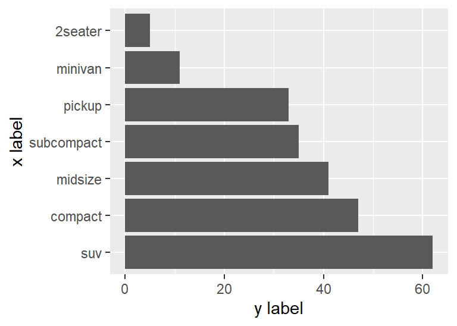

```r
ggplot(mpg, aes(x = fct_infreq(class))) + geom_bar() +
  coord_flip() +
  labs(x = "x label", y = "y label")
```

נעטוף אותו בפונקציה

```r
f_bar <- function(data, mapping){
  ggplot(data, mapping) + geom_bar() + coord_flip()
}

f_bar(mpg, aes(x = fct_infreq(class)))
```

[output not shown]

כעת נשתמש ב- **embrace** כדי לכתוב את הקוד יותר פשוט:

```r
f_bar2 <- function(data, var, title = NULL){
  ggplot(data, aes(x = fct_infreq({{var}}))) + geom_bar() + coord_flip() +
    labs(title = title)
}

f_bar2(mpg, class, title = "cars class distribution")
```

[output not shown]

כעת, נסביר מדוע השתמשנו ב-`NULL` עבור הכותרת.

## 11.2 using default values

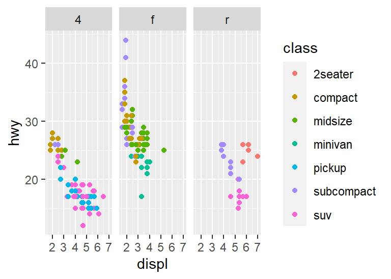

```r
plot_mpg <- function(colour_var, facet_var) {
  ggplot(mpg) +
    geom_point(aes(displ, hwy, colour = {{colour_var}})) +
    facet_wrap(vars({{facet_var}}))
}

plot_mpg(class, drv)
```

```r
plot_mpg(class)
```

```
## Error: At least one layer must contain all faceting variables: `<empty>`.
## * Plot is missing `<empty>`
## * Layer 1 is missing `<empty>`
```

צריך להשלים את זה עם NULL

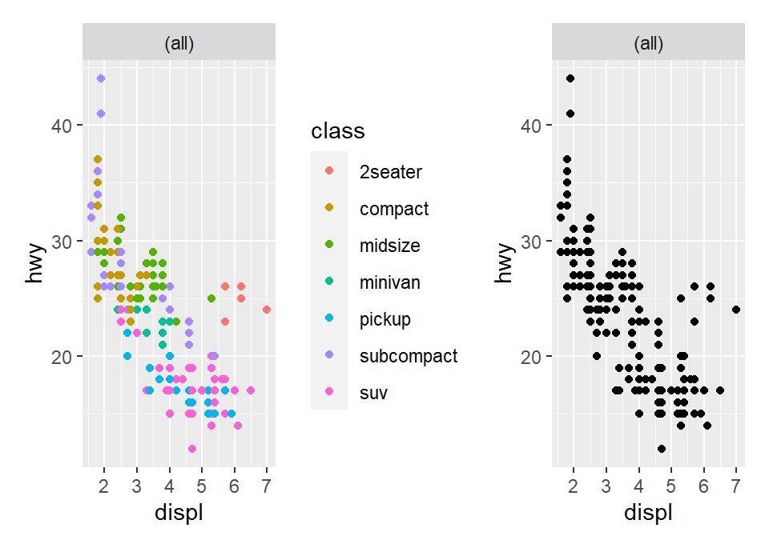

```r
p1 <- plot_mpg(class, NULL)
p2 <-plot_mpg(NULL, NULL)
p1 + p2
```

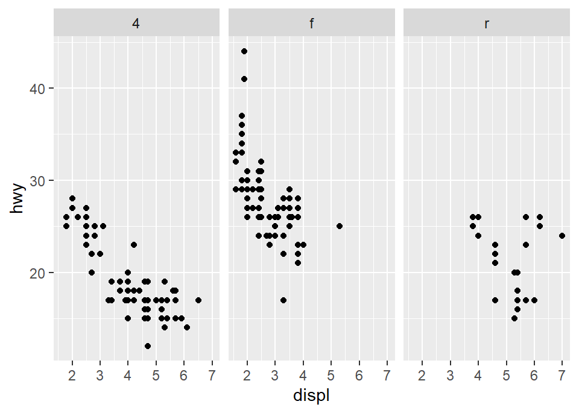

```r
plot_mpg(NULL, drv)
```

נפתור את זה באמצעות הגדרת ברירת מחדל לארגומנטים

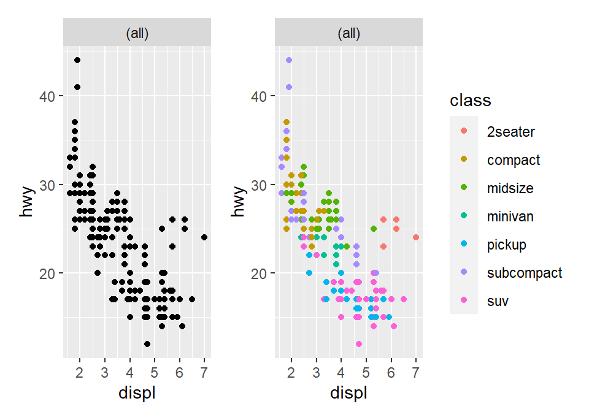

```r
plot_mpg <- function(colour_var= NULL, facet_var = NULL) {
  ggplot(mpg) +
    geom_point(aes(displ, hwy, colour = {{colour_var}})) +
    facet_wrap(vars({{facet_var}}))
}

p1 <- plot_mpg()
p2 <- plot_mpg(class)
p1 + p2
```

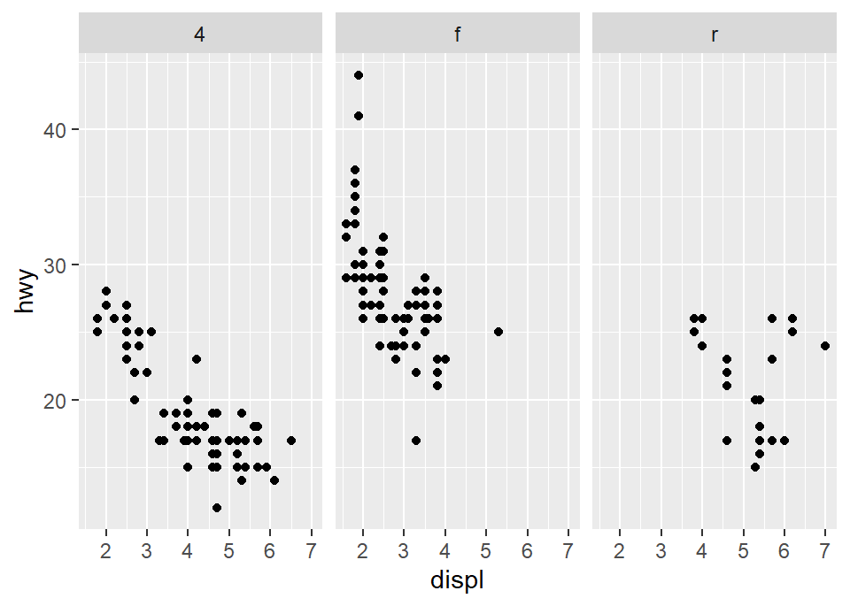

```r
plot_mpg( facet_var = drv)
```

## 11.3 edit component values

כל רכיב בתרשים `ggplot` הוא אובייקט. אפשר להקצות אובייקט ולתת לו שם של משתנה.

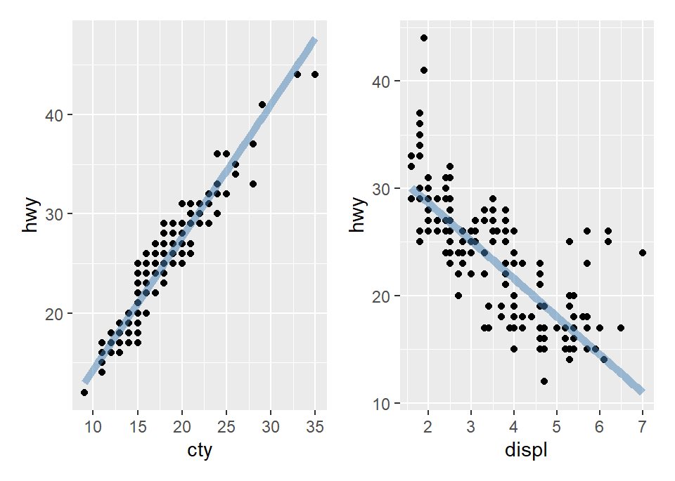

```r
bestfit <- geom_smooth( method = "lm",  se = FALSE, colour = alpha("steelblue", 0.5), size = 2)

p1 <- ggplot(mpg, aes(cty, hwy)) +
  geom_point() +
  bestfit

p2 <- ggplot(mpg, aes(displ, hwy)) +
  geom_point() +
  bestfit

p1 + p2
## `geom_smooth()` using formula 'y ~ x'
## `geom_smooth()` using formula 'y ~ x'
```

זו דרך מצוינת לצמצם כפילויות של קוד.  
אפשר להרחיב את הפונקציה `bestfit` כך שתהיה יותר כללית.  
הפונקציה הבאה מאפשרת בחירה של נוסחאת מודל הרגרסיה, צבע הקו וגודלו.

```r
geom_lm <- function(formula = y ~ x, colour = alpha("steelblue", 0.5), size = 2, ...) {

  geom_smooth(formula = formula, method = "lm", colour = colour,
              size = size, ...)

}
```

אפשר להשתמש במאפייני ברירת המחדל

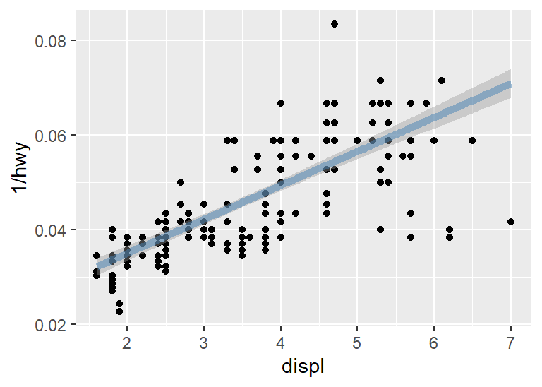

```r
ggplot(mpg, aes(displ, 1 / hwy)) +
  geom_point() +
  geom_lm()
```

אפשר לשנות את הנוסחאה והצבע

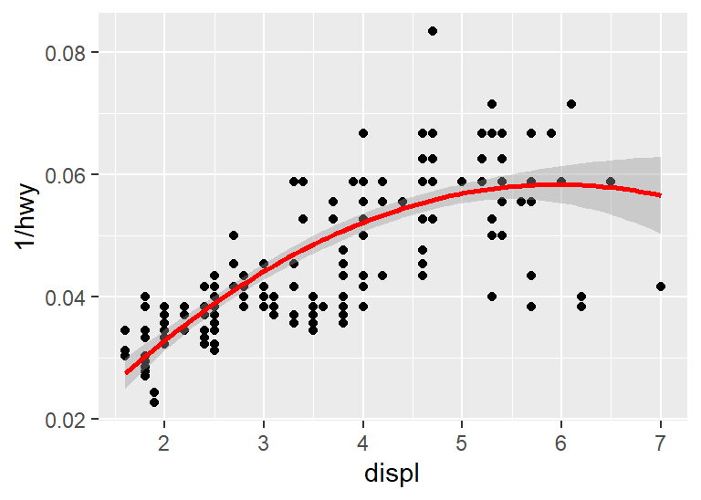

```r
ggplot(mpg, aes(displ, 1 / hwy)) +
  geom_point() +
  geom_lm(y ~ poly(x, 2), size = 1, colour = "red")
```

לא הגדרנו האם להציג או לא להציג את סטיית התקן, אבל כן הגדרנו את ה-`…`. אפשר להעביר ארגומנט ל- `geom_smooth`. נבטל את הצגת סטיית התקן:

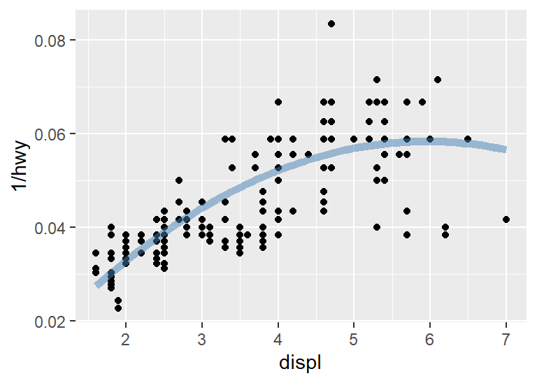

```r
ggplot(mpg, aes(displ, 1 / hwy)) +
  geom_point() +
  geom_lm(y ~ poly(x, 2), se = FALSE)
```

## 11.4 Multiple components

אפשר להוסיף מספר רכיבים תוך שימוש ב-`list`.

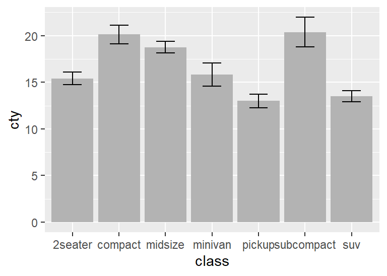

```r
geom_mean <- function() {
  list(
    stat_summary(fun = "mean", geom = "bar", fill = "grey70"),
    stat_summary(fun.data = "mean_cl_normal", geom = "errorbar", width = 0.4)
  )
}

ggplot(mpg, aes(class, cty)) + geom_mean()
```

אם הרשימה כוללת רכיבים שהם `NULL` הם לא יוצגו. זה מאפשר להוסיף רכיבים ברשימה באמצעות תנאי `if`:

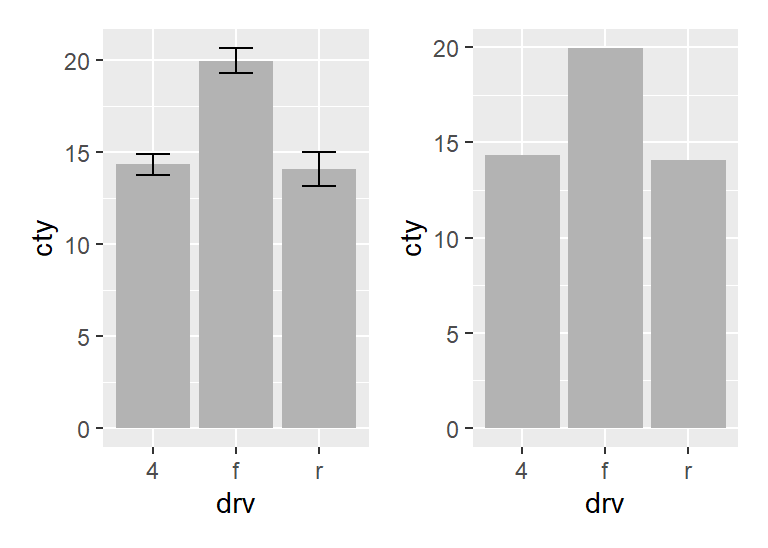

```r
geom_mean <- function(se = TRUE) {
  list(
    stat_summary(fun = "mean", geom = "bar", fill = "grey70"),
    if (se)
      stat_summary(fun.data = "mean_cl_normal", geom = "errorbar", width = 0.4)
  )
}


p1 <- ggplot(mpg, aes(drv, cty)) + geom_mean()

p2 <- ggplot(mpg, aes(drv, cty)) + geom_mean(se = FALSE)

p1 + p2
```